# ForeCasting Methods Project

Group

01/05/2022

## 2 Time series graphics

In this section the group will explore the dataset by ploting time series graphics and analyzing them, this section is really important as it provides the group an overall view of the temperature changing through the time and allows the group to identify possible patterns, such as trends, cycles and seasonalities during the time.

### General overview of the dataset

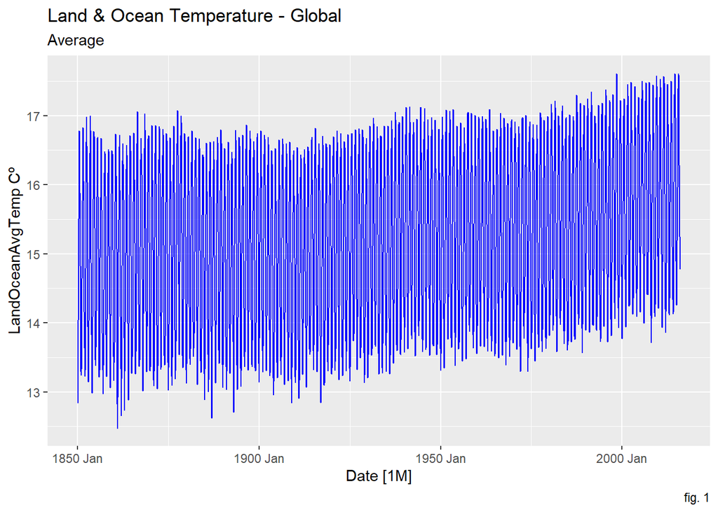

```r
GlobalTemp %>% autoplot(LandOceanAvgTemp)+
  geom_line(color="blue")+
  labs(title = "Land & Ocean Temperature - Global",
       subtitle = "Average",
       y="LandOceanAvgTemp Cº",
       caption = "fig. 1")
```

[figure not shown]

```r
GlobalCountryTemp %>% filter(Country == "Brazil") %>% autoplot(LandAvgTemp)+
  geom_line(color="green")+
  labs(title = "Land Temperature in Brazil - Since 1850",
       subtitle="Average",
       y="LandAvgTemp Cº",
       caption = "fig. 2")
```

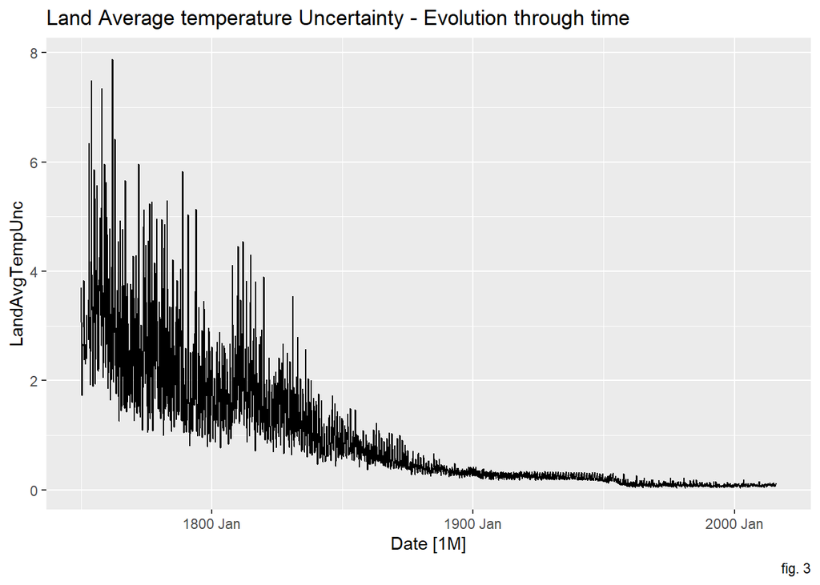

```r
GlobalCountryTemp %>% filter(Country=="Global") %>% autoplot(LandAvgTempUnc)+
  labs(title = "Land Average temperature Uncertainty - Evolution through time",
       caption = "fig. 3")
```

The dataset provides three different views that can be combined and analysed in multiple different ways.

The first view is the Global Land & Ocean average temperature (see fig. 1), it provides an interesting sight on how the combination of both land and ocean temperature has been changing since 1850.

The central view of the dataset is the Land temperature analysis, which can be divided into two parts:

- A global analysis that contains average, max and min temperature values
- A more narrow analysis by country that allows us to observe particular countries average temperatures over the years. Note that the years in analyse may differ from country to country due to missing data in the dataset, especially for years before 1900. Figure 2 shows the time series of Land Temperature of Brazil.

The final view is related with the uncertainty of the average temperature values and how it has changed over time (see fig. 3).

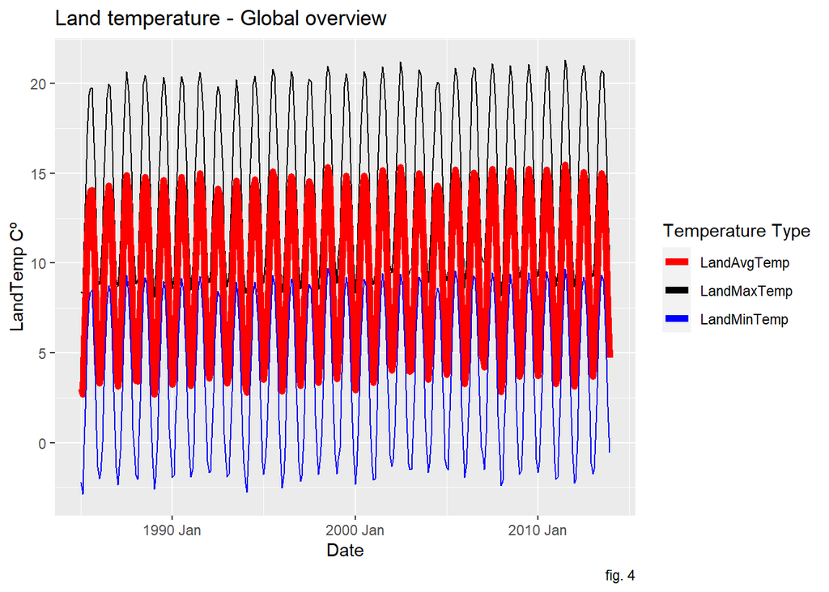

```r
GlobalTempV %>% ggplot()+
  geom_line(data=GlobalTempV, aes(Date, LandMaxTemp, col="LandMaxTemp"))+
  geom_line(data=GlobalTempV, aes(Date,LandAvgTemp,col="LandAvgTemp"),lwd=2)+
  geom_line(data=GlobalTempV, aes(Date, LandMinTemp, col="LandMinTemp"))+
  labs(title = "Land temperature - Global overview",
       y="LandTemp Cº",
       color="Temperature Type",
       caption = "fig. 4")+
  scale_color_manual(values= c("red","black","blue"))
```

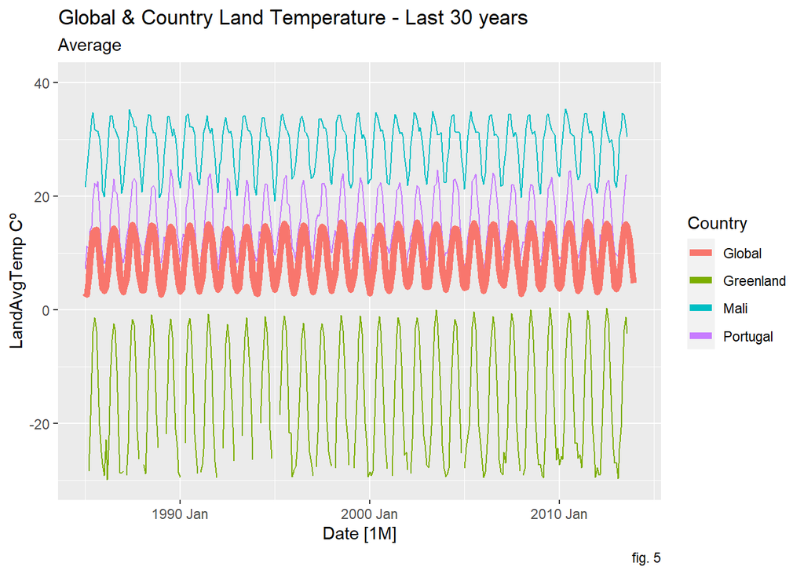

```r
GlobalCountryTemp %>% filter(Country %in% countries) %>% filter(year(Date)>1984) %>% autoplot(LandAvgTemp)+
  geom_line(data=GlobalTempV ,aes(Date, LandAvgTemp, col= "Global"),lwd=2)+
  labs(title= "Global & Country Land Temperature - Last 30 years",
            subtitle = "Average",
            y= "LandAvgTemp Cº",
       caption = "fig. 5")+
  ylim(-30,40)+
  theme(legend.position = "right")
```

Figure 5 shows the average temperature in the last 30 years of three selected countries and “global”. As we start looking at these time series plots we can see that the temperature behaves differently according to the countries analysed, some countries belong to hot regions like Mali and even Portugal and therefore have higher temperatures while other countries like Greenland are in more northern zones and have colder temperatures. The global temperature is nothing else but the weighted average of the temperature of all countries in the original dataset and therefore it appears on the “middle” of the time series graph. The same reasoning can be applied to the max and min global temperature in figure 4.

When we take a closer look to these graphs it’s possible to start observing some seasonal and trending patterns. Regarding the trending patterns, we can clearly see a very smooth crescent trend when it comes to land and ocean temperatures (fig. 1), which makes sense as a result of a direct effect of the global warming in the temperature, making it rise. On the other hand, there is a very clear decrescent trending on the temperature uncertainty (fig. 3), which makes sense from a point where as the time pass, the practices to measure temperature are better and more precise.

Looking now at the seasonal pattern, when we highlight the two graphs starting from 1985 onwards (fig. 4 and 5), it becomes explicit that there is a seasonal behavior every year. There are four seasons (winter, spring, summer and autumn) and we can clearly see that each of those has its temperature characteristics.

### Focusing on seasonality, cycles and trends

In this section, the objective is to focus on the seasonal and trending pattern identified previously and confirm them.

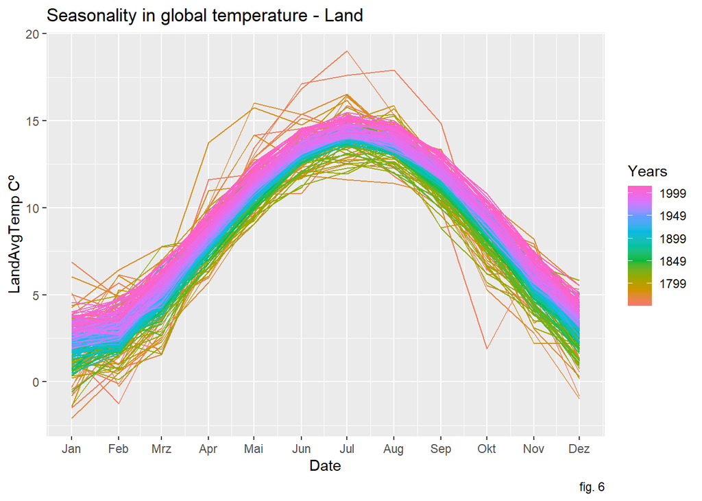

```r
#seasonal and trending
GlobalCountryTemp %>%
  filter(Country=="Global") %>%
  gg_season(LandAvgTemp)+
  labs(title = "Seasonality in global temperature - Land",
       y="LandAvgTemp Cº",
       color="Years",
       caption = "fig. 6")
```

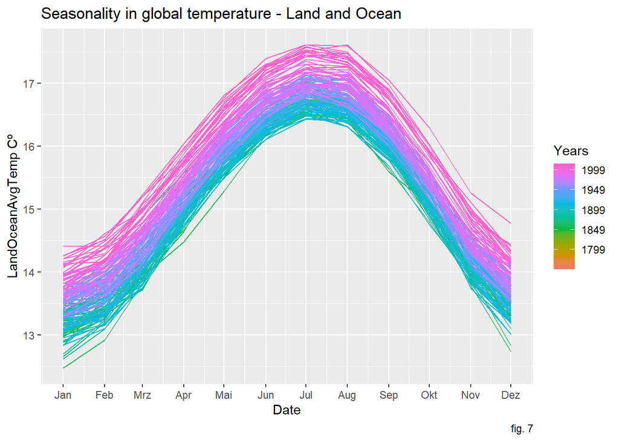

```r
GlobalCountryTemp %>%
  filter(Country=="Global") %>%
  gg_season(LandOceanAvgTemp)+
  labs(title = "Seasonality in global temperature - Land and Ocean",
       y="LandOceanAvgTemp Cº",
       color="Years",
       caption = "fig. 7")
```

We can clearly see that in winter months (December, January and February), the temperature reaches the lowest values while in summer months (June, July, August), the temperature reaches its peak. Besides showing the seasonality, this graph clearly shows the crescent trending as the years go by. The lines that represent the years keep going up in the graph.

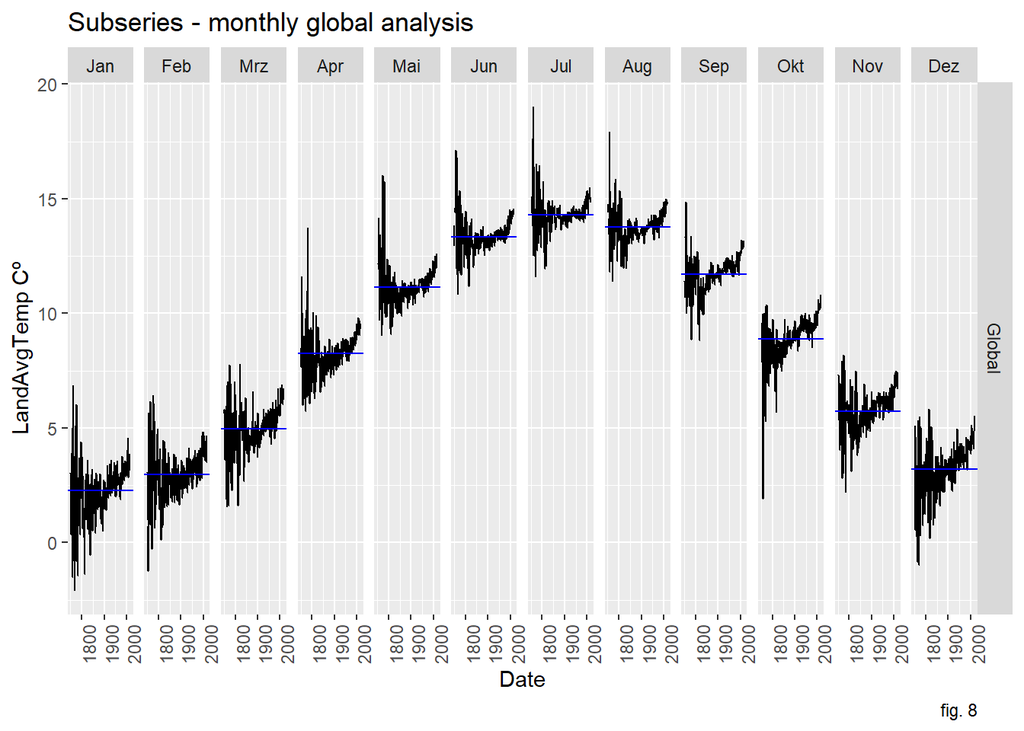

```r
#subseries
GlobalCountryTemp %>%
  filter(Country=="Global") %>%
  gg_subseries(LandAvgTemp)+
  labs(title = "Subseries - monthly global analysis",
       y="LandAvgTemp Cº",
       caption = "fig. 8")
```

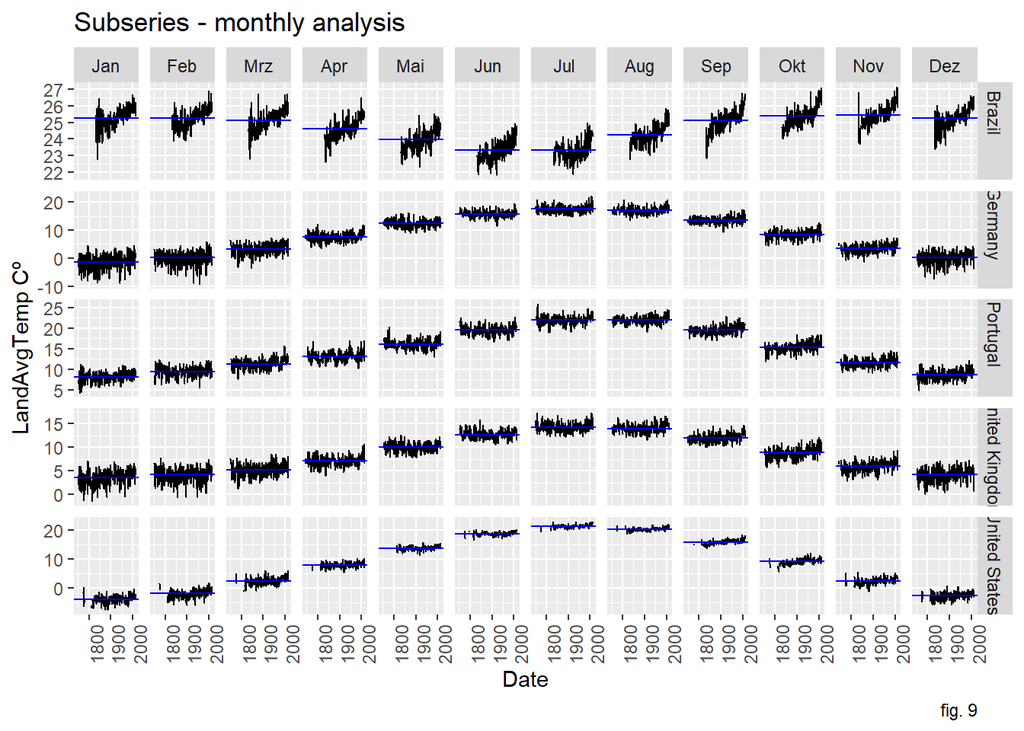

```r
GlobalCountryTemp %>%
  filter(Country %in% countries2) %>%
  gg_subseries(LandAvgTemp)+
  labs(title = "Subseries - monthly analysis",
         y="LandAvgTemp Cº",
       caption = "fig. 9")
```

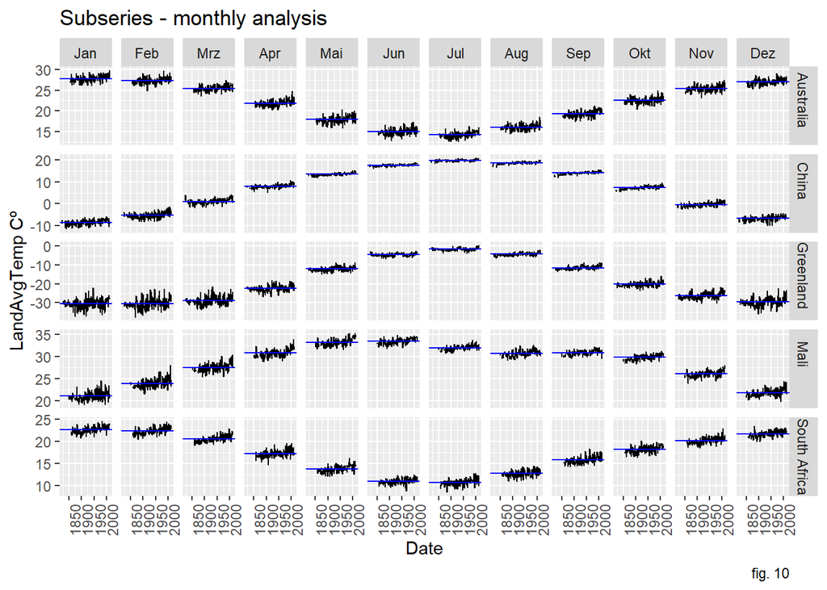

```r
GlobalCountryTemp %>%
  filter(Country %in% countries3) %>%
  gg_subseries(LandAvgTemp)+
  labs(title = "Subseries - monthly analysis",
         y="LandAvgTemp Cº",
       caption = "fig. 10")
```

The subseries analysis also provides some more details regarding the seasonality and trending.

Especially figure 8 shows clearly high discrepancies in early 1800 temperature values due to the high uncertainty. However, it is still clear to see that there is a growing trend, at a global perspective.

The country subseries analysis in figure 9 and 10 reveals again a strong seasonality. However, it also shows a new perspective regarding the seasonality. Some countries have their seasonality “swaped” when compared to the global seasonality. This is due to the fact that the temperature in the countries of the northern hemisphere is the opposite of that in the countries of the southern hemisphere: If it’s summer in the north (June, July, August), it’s winter in the south. Nevertheless we can still identify the growing trend of the temperature in most countries.

### Looking at autocorrelation and white noise

Lastly, we analyse the autocorrelation and examine whether white noise exists.

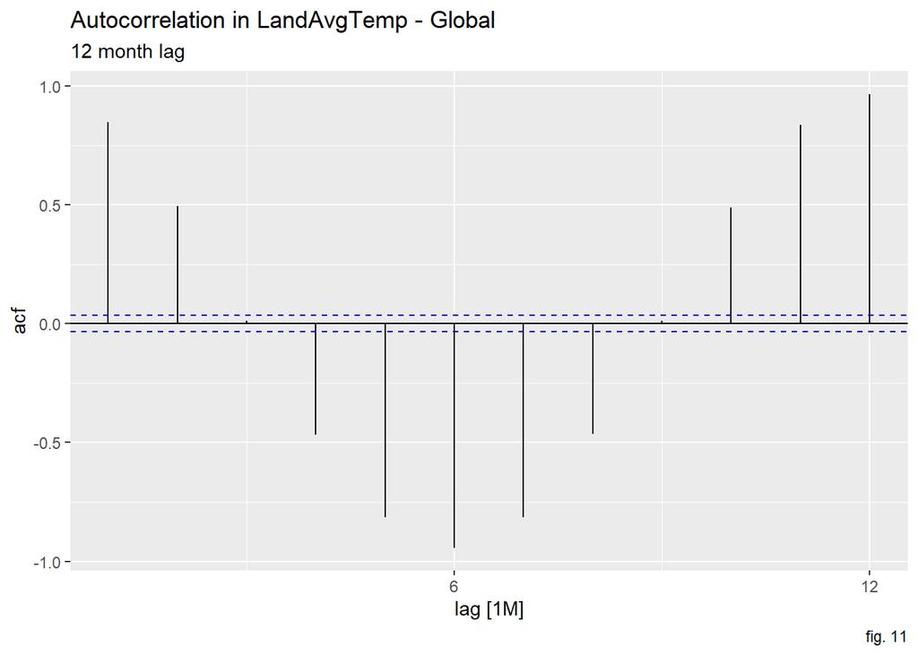

```r
#6, 12 or 24 lags--> monthly data
#In this case 12 looks the best as it captures all months of one year

GlobalCountryTemp %>% filter(Country=="Global") %>% ACF(LandAvgTemp,lag_max = 12) %>% autoplot()+
  labs(title = "Autocorrelation in LandAvgTemp - Global",
       subtitle = "12 month lag",
       caption = "fig. 11")
```

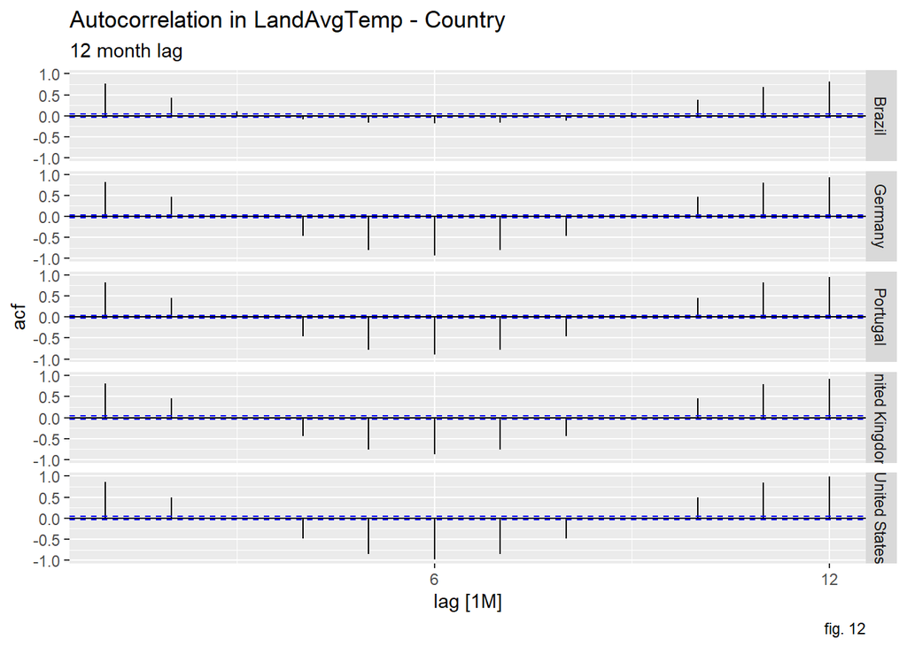

```r
GlobalCountryTemp %>%
  filter(Country %in% countries2)%>% ACF(LandAvgTemp,lag_max = 12) %>% autoplot()+
  labs(title = "Autocorrelation in LandAvgTemp - Country",
       subtitle = "12 month lag",
       caption = "fig. 12")
```

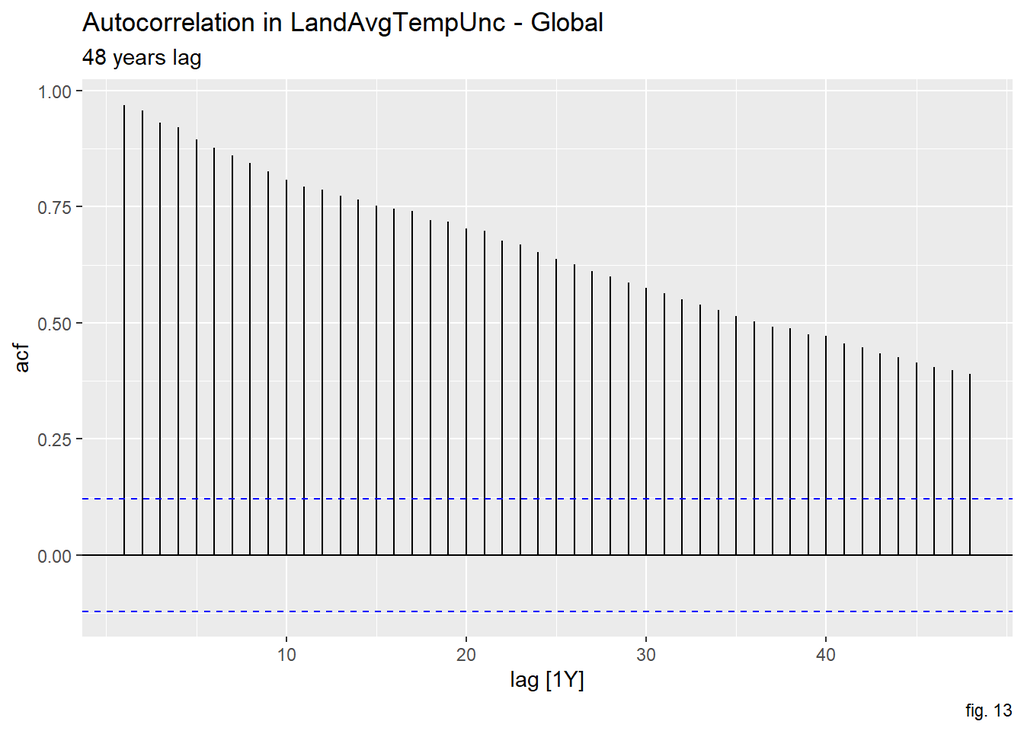

```r
#transforming it into yearly data since there is no seasonality
#showing the first 48 years
uncertainty<- GlobalCountryTemp %>% filter(Country=="Global") %>%
  mutate(Year= year(Date)) %>%
  as_tibble(GlobalCountryTemp) %>%
  group_by(Year)%>%
  select(-Date) %>%
  summarise(LandAvgTempUnc= mean(LandAvgTempUnc))

uncertainty %>%as_tsibble(index=Year) %>% filter(Year> "1752") %>%
  ACF(LandAvgTempUnc, lag_max = 48) %>% autoplot()+
  labs(title = "Autocorrelation in LandAvgTempUnc - Global",
       subtitle = "48 years lag",
       caption = "fig. 13")
```

Since our autocorrelation values are mostly above the significant interval our time series don’t follow “white noise”.

## 3. Time Series Decomposition

Time series data can have a variety of patterns, and it is often convenient to divide a time series into several components, each representing an underlying pattern category. In this chapter, the project group will use established methods to extract these components from the time series. This is done to improve the understanding of the time series, but also to improve forecast accuracy, which is discussed in the following chapters.

### Mathematical transformations

First we are going to see if the time series need adjustments. As we can see in the graphs below (see figure 14, 15 and 16) our variation does not change with the level of the time series. So, we will not use mathematical transformations.

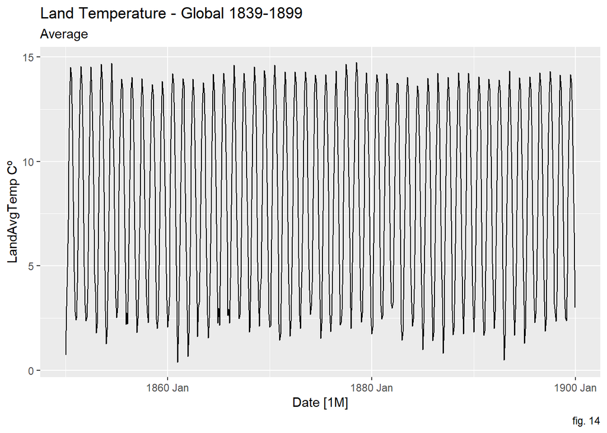

```r
GlobalTemp %>%
  filter(year(Date)>1838, year(Date)<1900) %>%
  autoplot(LandAvgTemp)+
  geom_line()+
  labs(title = "Land Temperature - Global 1839-1899",
       subtitle = "Average",
       y="LandAvgTemp Cº",
       caption = "fig. 14")
```

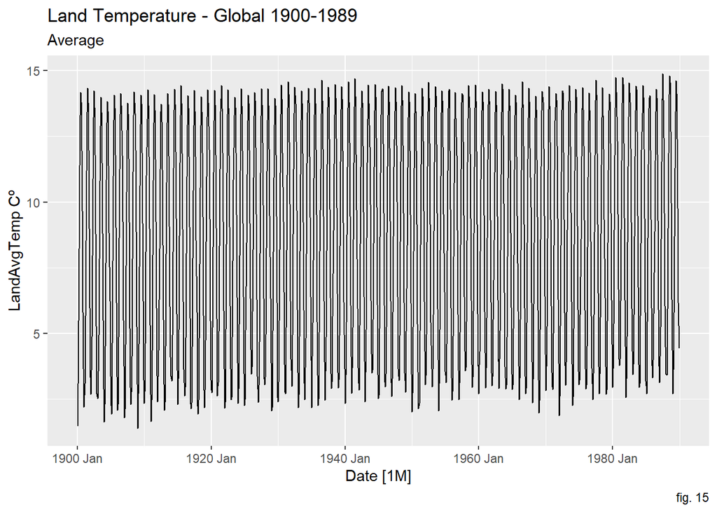

```r
GlobalTemp %>%
  filter(year(Date)>=1900, year(Date)<1990) %>%
  autoplot(LandAvgTemp)+
  geom_line()+
  labs(title = "Land Temperature - Global 1900-1989",
       subtitle = "Average",
       y="LandAvgTemp Cº",
       caption = "fig. 15")
```

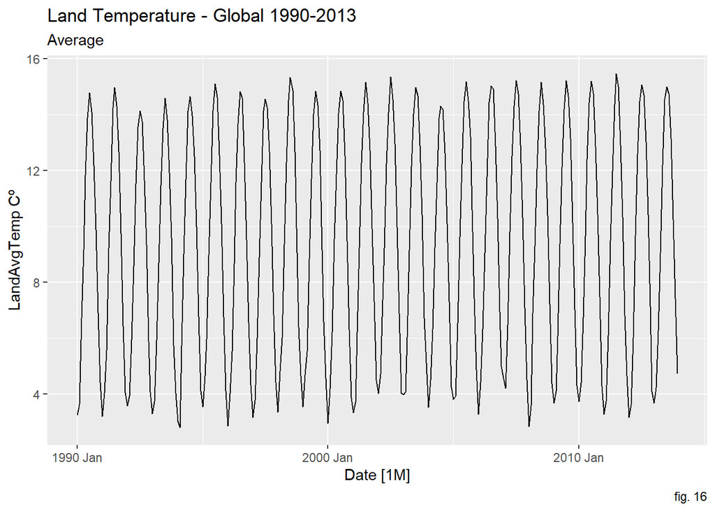

```r
GlobalTemp %>%
  filter(year(Date)>=1990, year(Date)<2014) %>%
  autoplot(LandAvgTemp)+
  geom_line()+
  labs(title = "Land Temperature - Global 1990-2013",
       subtitle = "Average",
       y="LandAvgTemp Cº",
       caption = "fig. 16")
```

### Time series Components

Now we will decompose the series into the seasonal components, the trend-cycle component and a remainder component. As the variations around the trend are of similar magnitudes over time, we will use an Additive Decomposition.

```r
# Show components of land & ocean global average temperature

GlobalTemp %>%
  select(LandOceanAvgTemp) -> land_ocean_global_temp

dec <- land_ocean_global_temp %>%
  model(stl = STL(LandOceanAvgTemp))

components(dec)
```

```
## # A dable: 1,992 x 7 [1M]
## # Key:     .model [1]
## # :        LandOceanAvgTemp = trend + season_year + remainder
##    .model     Date LandOceanAvgTemp trend season_year remainder season_adjust
##    <chr>     <mth>            <dbl> <dbl>       <dbl>     <dbl>         <dbl>
##  1 stl    1850 Jan             12.8  14.9      -1.81   -0.231            14.6
##  2 stl    1850 Feb             13.6  14.9      -1.55    0.266            15.1
##  3 stl    1850 Mrz             14.0  14.9      -0.970   0.139            15.0
##  4 stl    1850 Apr             14.7  14.9      -0.119  -0.0895           14.8
##  5 stl    1850 Mai             15.5  14.9       0.787  -0.157            14.7
##  6 stl    1850 Jun             16.4  14.9       1.48   -0.00645          14.9
##  7 stl    1850 Jul             16.8  14.9       1.86    0.0428           14.9
##  8 stl    1850 Aug             16.7  14.9       1.69    0.148            15.0
##  9 stl    1850 Sep             15.9  14.9       0.991   0.0139           14.9
## 10 stl    1850 Okt             14.8  14.9       0.102  -0.153            14.7
## # ... with 1,982 more rows
```

```r
# Show components of land global average temperature

GlobalTemp %>%
  select(LandAvgTemp) -> land_global_temp

dec2 <- land_global_temp %>%
  model(stl = STL(LandAvgTemp))

components(dec2)
```

```
## # A dable: 1,992 x 7 [1M]
## # Key:     .model [1]
## # :        LandAvgTemp = trend + season_year + remainder
##    .model     Date LandAvgTemp trend season_year remainder season_adjust
##    <chr>     <mth>       <dbl> <dbl>       <dbl>     <dbl>         <dbl>
##  1 stl    1850 Jan       0.749  7.85      -6.13     -0.975          6.87
##  2 stl    1850 Feb       3.07   7.87      -5.54      0.745          8.61
##  3 stl    1850 Mrz       4.95   7.88      -3.66      0.732          8.61
##  4 stl    1850 Apr       7.22   7.90      -0.494    -0.186          7.71
##  5 stl    1850 Mai      10.0    7.91       2.77     -0.675          7.24
##  6 stl    1850 Jun      13.2    7.93       5.11      0.114          8.04
##  7 stl    1850 Jul      14.5    7.95       6.34      0.205          8.15
##  8 stl    1850 Aug      14.0    7.96       5.59      0.491          8.45
##  9 stl    1850 Sep      11.5    7.97       3.37      0.157          8.13
## 10 stl    1850 Okt       8.09   7.99       0.646    -0.542          7.45
## # ... with 1,982 more rows
```

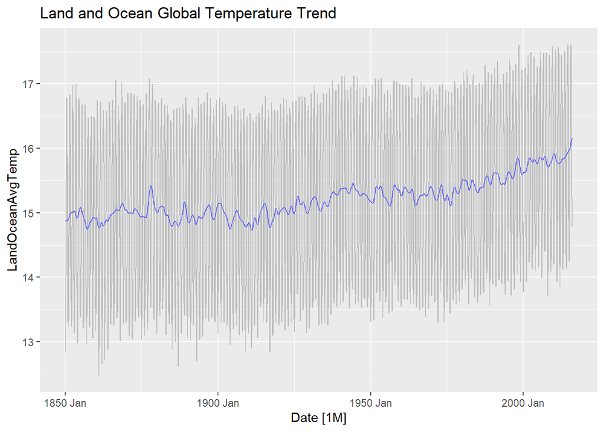

```r
land_ocean_global_temp %>%
  autoplot(LandOceanAvgTemp, color = 'gray') +
  autolayer(components(dec), trend, color = '#6666ff') +
  ggtitle('Land and Ocean Global Temperature Trend')
```

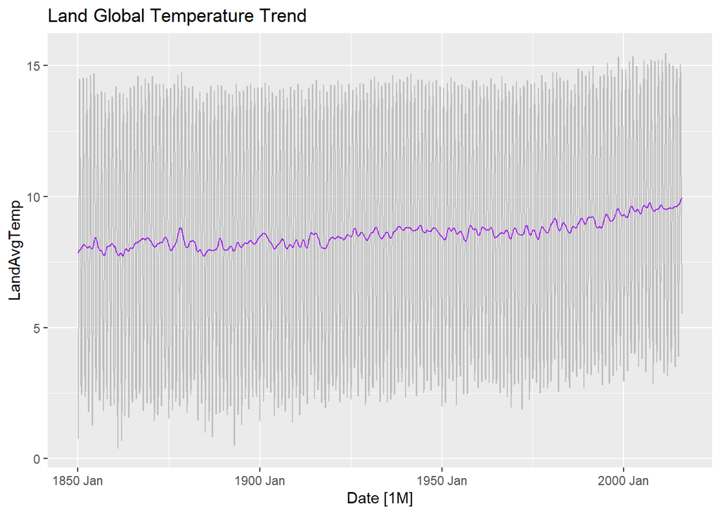

```r
land_global_temp %>%
  autoplot(LandAvgTemp, color = 'gray') +
  autolayer(components(dec2), trend, color = 'purple') +
  ggtitle('Land Global Temperature Trend')
```

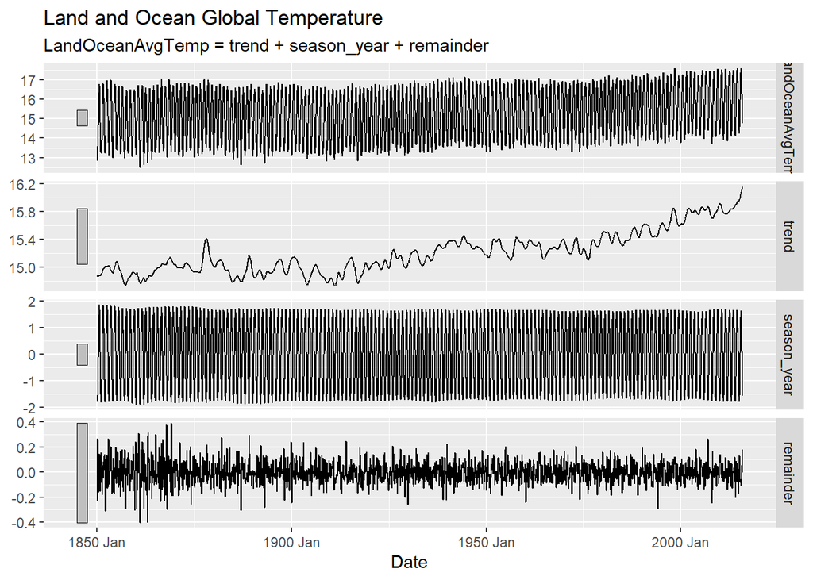

```r
components(dec) %>%
  autoplot() + ggtitle('Land and Ocean Global Temperature')
```

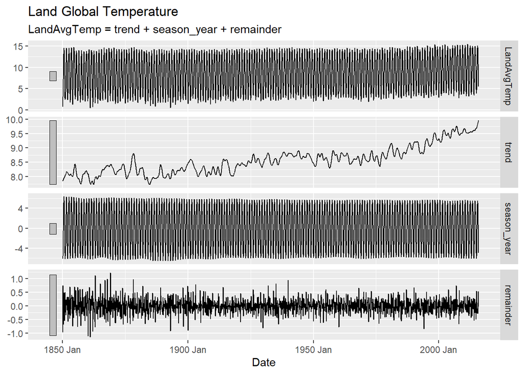

```r
components(dec2) %>%
  autoplot() + ggtitle('Land Global Temperature')
```

Note: we can see the trend is clearly going up.

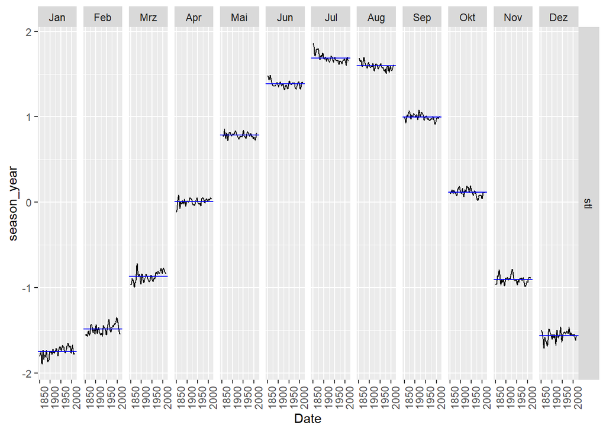

```r
components(dec) %>% gg_subseries(season_year)
```

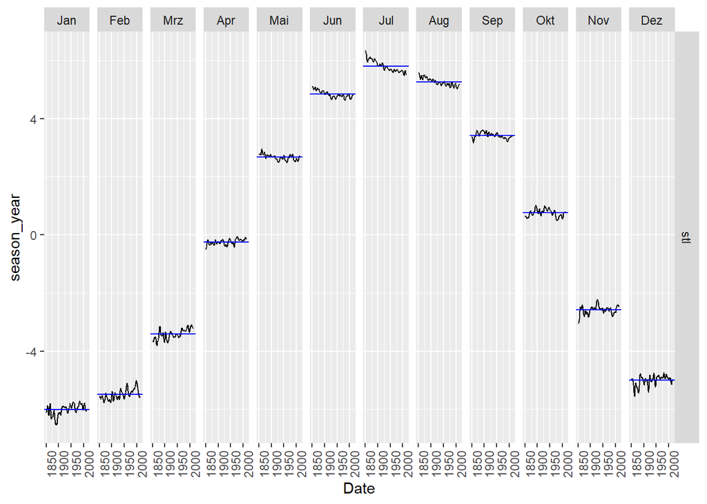

```r
components(dec2) %>% gg_subseries(season_year)
```

#### Analyzing Europe Trend

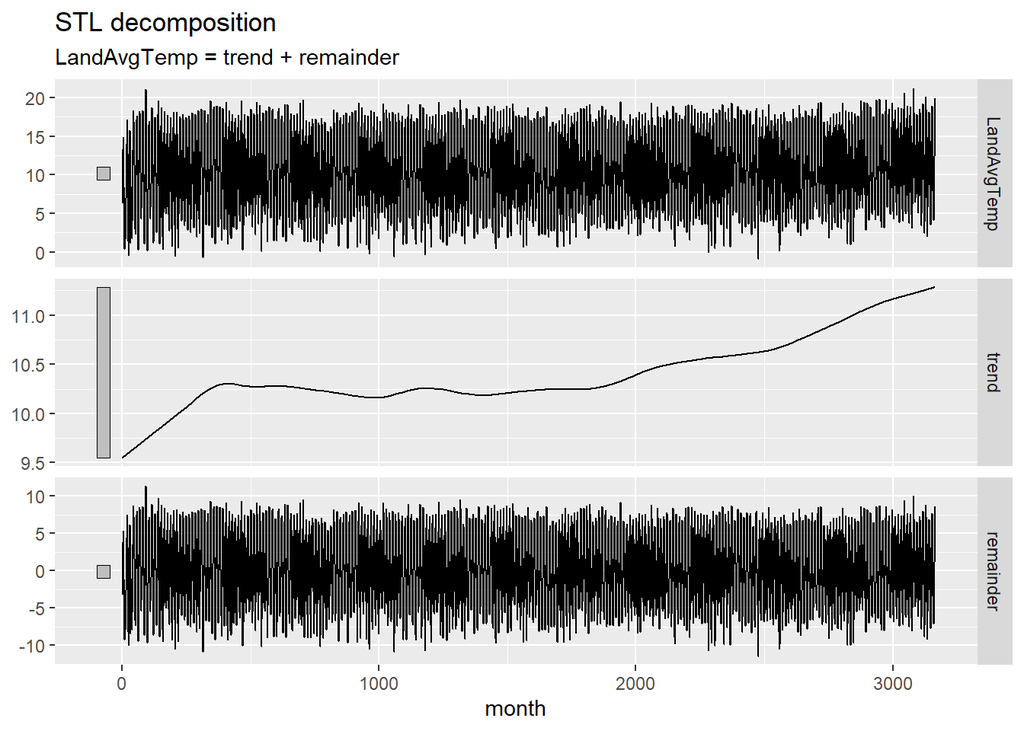

```r
europe <- c('Portugal', 'Germany', 'United Kingdom')

GlobalCountryTemp %>%
  filter(Country %in% europe) %>%
  select(Country, LandAvgTemp) %>%
  index_by(Date) %>%
  summarise(LandAvgTemp = mean(LandAvgTemp)) %>% na.omit() %>%
  mutate(month= row_number()) %>%
  select(LandAvgTemp, everything()) %>%
  update_tsibble(index=month, regular = TRUE)-> land_temp_mean_europe

deceurope<- land_temp_mean_europe %>%
  model(stl = STL(LandAvgTemp~ trend(window=7)+
                    season(window = "periodic"),
    robust = TRUE))

components(deceurope) %>% autoplot()
```

## 4. The forecaster’s toolbox

In the previous chapters we have already prepared and visualized our data in order to gain a good understanding of our data. Now, we will use some benchmark forecasting methods to forecast our time series. Moreover, techniques for calculating forecast intervals and methods for assessing forecast accuracy will be applied.

### Specifying a model

Looking at our data allows us to identify common patterns, and subsequently specify an appropriate model. We have seen in the previous chapters that our time series for Land Average Temperature and Land & Ocean Average temperature reveal a seasonal and a trend pattern. Now, we will check which type of forecasting method is appropriate for this type of time series.

There are several simple forecasting methods. The “Average method” and the “Naïve method” are suitable for time series without any seasonality or trend pattern. Therefore, we won’t use these methods for our time series.

The “Seasonal naïve method” is appropriate for data with seasonality and the “Drift Method” for data with a trend pattern. For that reason, we will know apply these forecasting methods to our data and visualize the results.

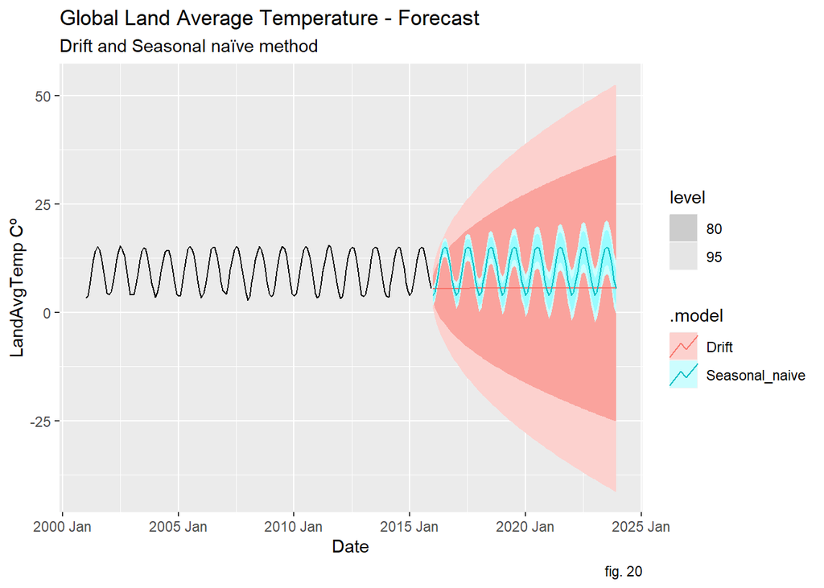

```r
GlobalCountryTemp %>%
  filter(Country=="Global") %>%
  fill(LandAvgTemp, .direction = "down") %>%
  model(Seasonal_naive = SNAIVE(LandAvgTemp),
        Drift = RW(LandAvgTemp ~ drift())
        ) %>% forecast(h = "8 years") %>%
  autoplot((filter(GlobalCountryTemp, year(Date) > 2000))) +
  labs(title = "Global Land Average Temperature - Forecast",
       subtitle = "Drift and Seasonal naïve method",
       y="LandAvgTemp Cº",
       caption = "fig. 20")
```

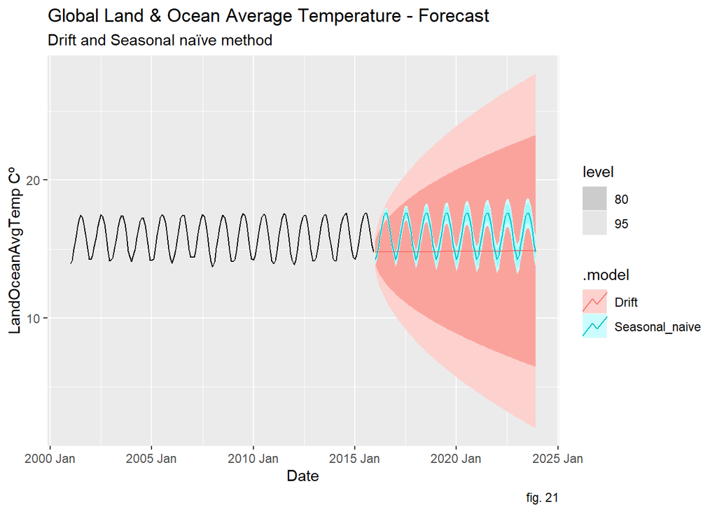

```r
GlobalCountryTemp %>%
  filter(Country=="Global") %>%
  fill(LandOceanAvgTemp, .direction = "down") %>%
  model(Seasonal_naive = SNAIVE(LandOceanAvgTemp),
        Drift = RW(LandOceanAvgTemp ~ drift())
        ) %>% forecast(h = "8 years") %>%
  autoplot(filter(GlobalCountryTemp, year(Date) > 2000)) +
  labs(title = "Global Land & Ocean Average Temperature - Forecast",
       subtitle = "Drift and Seasonal naïve method",
       y="LandOceanAvgTemp Cº",
       caption = "fig. 21")
```

The figures above show the forecasts for the next 8 years (from 2016 onward) estimated by the “Seasonal naïve method” and the “Drift Method” for the times Series “Global Land Average temperature” and “Global Land & Ocean Temperature”, respectively. It can be seen that the area for the prediction intervals is high, which means that there is a high uncertainty in the forecasts. One reason for this may be that one method is suitable for data with seasonality and the other method for data with trend. But in fact our time series has both seasonality and trend.

Let’s try to apply the “Drift Method” on the seasonal adjusted data, so that we capture both components in our forecast: Seasonality and Trend.

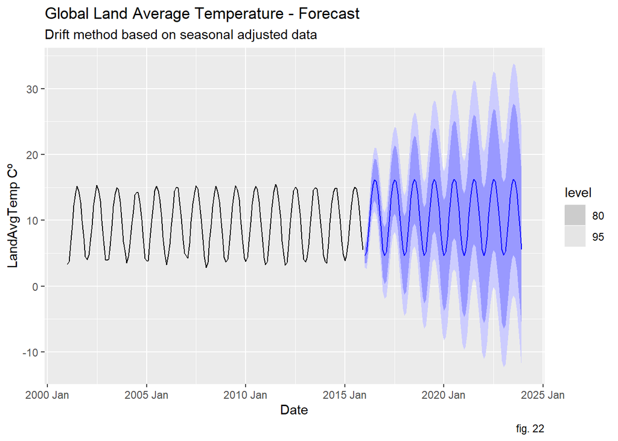

```r
GlobalCountryTemp %>%
  filter(Country=="Global") %>%
  fill(LandAvgTemp, .direction = "down") %>%
  model(stlf = decomposition_model(
    STL(LandAvgTemp ~ trend(window = 7), robust = TRUE),
        Drift = RW(season_adjust ~ drift())
    )) %>%
  forecast(h = "8 years") %>%
  autoplot(filter(GlobalCountryTemp, year(Date) > 2000)) +
  labs(title = "Global Land Average Temperature - Forecast",
       subtitle = "Drift method based on seasonal adjusted data",
       y="LandAvgTemp Cº",
       caption = "fig. 22")
```

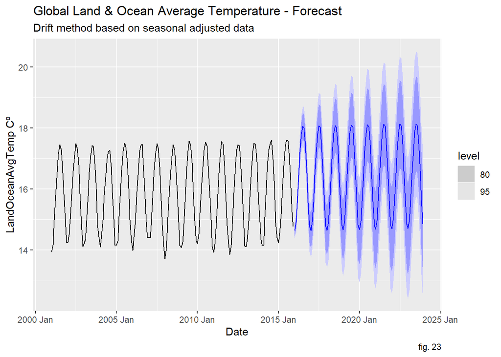

```r
GlobalCountryTemp %>%
  filter(Country=="Global") %>%
  fill(LandOceanAvgTemp, .direction = "down") %>%
  filter(!is.na(LandOceanAvgTemp)) %>%
  model(stlf = decomposition_model(
    STL(LandOceanAvgTemp ~ trend(window = 7), robust = TRUE),
        Drift = RW(season_adjust ~ drift())
    )) %>%
  forecast(h = "8 years") %>%
  autoplot(filter(GlobalCountryTemp, year(Date) > 2000)) +
  labs(title = "Global Land & Ocean Average Temperature - Forecast",
       subtitle = "Drift method based on seasonal adjusted data",
       y="LandOceanAvgTemp Cº",
       caption = "fig. 23")
```

The figures above show the forecasts for the next 8 years (from 2016 onward) estimated by the “Drift Method” based on the seasonal adjusted data (based on STL Decomposition) for the times Series “Global Land Average temperature” and “Global Land & Ocean Temperature”, respectively. The prediction intervals are still big, especially for the forecast of the “Global Land Average temperature”. When we compare the prediction interval to those of the “Seasonal naïve method” in figure 20 and 21 they seem to be even bigger.

In the following chapter we will calculate the forecasting accuracy and check if our intuition about the best method is true.

### Accuracy & performance evaluation

In this chapter we will divide our data in training and test sets to evaluate the forecasting accuracy. For this purpose the time series cross-validation is used. In this procedure, there are a number of test sets, each consisting of a single observation. The corresponding training set consists only of observations that occurred before the observation that forms the test set. By averaging over the test series the forecasting accuracy is calculated.

#### Global land average temperature forecast

```r
GlobalCountryTemp %>%
  filter(Country=="Global") %>%
  filter(year(Date)>=1990) %>%
  fill(LandAvgTemp, .direction = "down") %>%
  filter(!is.na(LandAvgTemp)) %>%
  stretch_tsibble(.init = 3, .step = 1) %>%
  model(Seasonal_naive = SNAIVE(LandAvgTemp),
        Drift = RW(LandAvgTemp ~ drift())
        ) %>% forecast(h = "8 years") %>%
  accuracy(GlobalCountryTemp)
```

```
## # A tibble: 2 x 11
##   .model    Country .type     ME   RMSE   MAE     MPE   MAPE   MASE  RMSSE  ACF1
##   <chr>     <chr>   <chr>  <dbl>  <dbl> <dbl>   <dbl>  <dbl>  <dbl>  <dbl> <dbl>
## 1 Drift     Global  Test  -5.77  19.9   9.53  -109.   140.   14.4   18.9   0.983
## 2 Seasonal~ Global  Test   0.113  0.455 0.355    1.06   5.30  0.539  0.432 0.319
```

```r
GlobalCountryTemp %>%
  filter(Country=="Global") %>%
  filter(year(Date)>=1990) %>%
  fill(LandAvgTemp, .direction = "down") %>%
  filter(!is.na(LandAvgTemp)) %>%
  stretch_tsibble(.init = 3, .step = 1) %>%
  model(stlf = decomposition_model(
    STL(LandAvgTemp ~ trend(window = 7), robust = TRUE),
        Drift = RW(season_adjust ~ drift())
    )) %>% forecast(h = "8 years") %>%
  accuracy(GlobalCountryTemp)
```

```
## # A tibble: 1 x 11
##   .model Country .type    ME  RMSE   MAE   MPE  MAPE  MASE RMSSE  ACF1
##   <chr>  <chr>   <chr> <dbl> <dbl> <dbl> <dbl> <dbl> <dbl> <dbl> <dbl>
## 1 stlf   Global  Test  -3.35  18.2  3.89 -51.0  57.5  5.90  17.3 0.988
```

In the figures above we can see the accuracy of the three different models for the Average global Land Temperature. The RMSE is a good way to choose the best forecasting model. The RMSE of the “Seasonal naïve method” is the smallest, followed by the “Drift Method” on seasonal adjusted data and then the normal “Drift method”.

#### Global land and ocean average temperature forecast

```r
GlobalCountryTemp %>%
  filter(Country=="Global") %>%
  filter(year(Date)>=1990) %>%
  fill(LandOceanAvgTemp, .direction = "down") %>%
  filter(!is.na(LandOceanAvgTemp)) %>%
  stretch_tsibble(.init = 3, .step = 1) %>%
  model(Seasonal_naive = SNAIVE(LandOceanAvgTemp),
        Drift = RW(LandOceanAvgTemp ~ drift())
        ) %>% forecast(h = "8 years") %>%
  accuracy(GlobalCountryTemp)
```

```
## # A tibble: 2 x 11
##   .model       Country .type      ME  RMSE   MAE     MPE  MAPE  MASE RMSSE  ACF1
##   <chr>        <chr>   <chr>   <dbl> <dbl> <dbl>   <dbl> <dbl> <dbl> <dbl> <dbl>
## 1 Drift        Global  Test  -1.66   5.88  2.79  -11.2   18.0  18.4  30.1  0.983
## 2 Seasonal_na~ Global  Test   0.0701 0.197 0.156   0.436  1.00  1.03  1.01 0.605
```

```r
GlobalCountryTemp %>%
  filter(Country=="Global") %>%
  filter(year(Date)>=1990) %>%
  fill(LandOceanAvgTemp, .direction = "down") %>%
  filter(!is.na(LandOceanAvgTemp)) %>%
  stretch_tsibble(.init = 3, .step = 1) %>%
  model(stlf = decomposition_model(
    STL(LandOceanAvgTemp ~ trend(window = 7), robust = TRUE),
        Drift = RW(season_adjust ~ drift())
    )) %>% forecast(h = "8 years") %>%
  accuracy(GlobalCountryTemp)
```

```
## # A tibble: 1 x 11
##   .model Country .type     ME  RMSE   MAE   MPE  MAPE  MASE RMSSE  ACF1
##   <chr>  <chr>   <chr>  <dbl> <dbl> <dbl> <dbl> <dbl> <dbl> <dbl> <dbl>
## 1 stlf   Global  Test  -0.952  5.40  1.20 -6.20  7.74  7.86  27.6 0.988
```

In the figures above we can see the accuracy of the three different models for the Average global Land & Ocean Temperature. By evaluating the RMSE we can again see that the forecasting accuracy of the “Seasonal naïve method” is the best, followed by the “Drift Method” on seasonal adjusted data and then the normal “Drift method”.